# Ford Gobike Data Exploration

## Investigation Overview

In this investigation, I wanted to look at the characteristics of Bike share and thier features, The main focus was on the duration of trip, age, user type and gender.

## Dataset Overview

> This document explores a dataset containing the trip data of the ford and it is the first regional and large-scale bicycle sharing system deployed in California and on the West Coast of the United States.

## Distribution of Trip Durations

Trip duration is in second and in the dataset taking on a very large range of values so We can not see clearly which the data looks highly skewed with a very long tail of data points, so we will Scale the x-axis to log-type scales for more clear vision. we will observe that Number of Trips increases starting from around 8000 to 12000 values, then starts to fall down around to 2000 values approximately. The duration of the trip is approximately centered on values which are less than 2000 seconds with peak around 500 seconds.

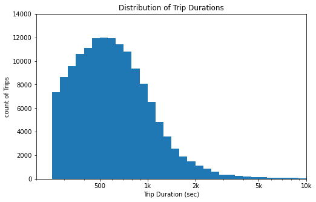

```python
# let us take the log scale for more clear vision

bins_log = 10 ** np.arange(2.4, np.log10(trip['duration_sec'].max()) + 0.05, 0.05)

plt.figure(figsize=[8, 5])
plt.hist(data = trip, x = 'duration_sec', bins = bins_log)

# The argument in the xscale() represents the axis scale type to apply.
plt.xscale('log')

plt.title('Distribution of Trip Durations')

# Labeling the axes
plt.xlabel('Trip Duration (sec)')
plt.ylabel('count of Trips')

# show the scale in x-axis will be 1K instead of 1000, and so on..
plt.xticks([500, 1e3, 2e3, 5e3, 1e4], [500, '1k', '2k', '5k', '10k'])

# set limits for y and x axis
plt.axis([200, 10000, 0, 14000])

# Dsiplay the plot
plt.show()
```

## Distribution of User Type

User Type has two categorical variables (Customer and Subscriber) and we will observe that The number of subscribers are much larger than the number of customers.

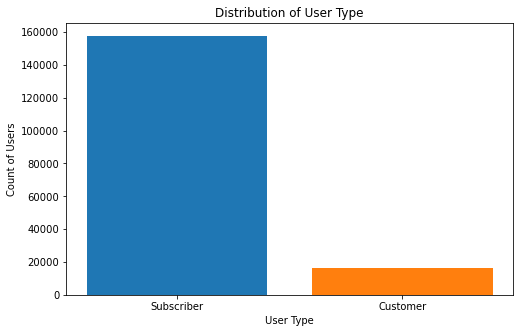

```python
# plotting types of users
# choose the bar chart where the user type have two Qualitative(Categorical) variables

#Qualitative palettes are built for nominal-type data.
plt.figure(figsize=[8,5])
plt.bar(x = trip['user_type'].value_counts().keys(), height = trip['user_type'].value_counts(), color = sb.color_palette(n_colors=9))
plt.title('Distribution of User Type')

# Labeling the axes
plt.xlabel('User Type')
plt.ylabel('Count of Users')

# Dsiplay the plot
plt.show()
```

## Distribution of Bike share for all trip

In this Distribution we will observe that The most of users are False.

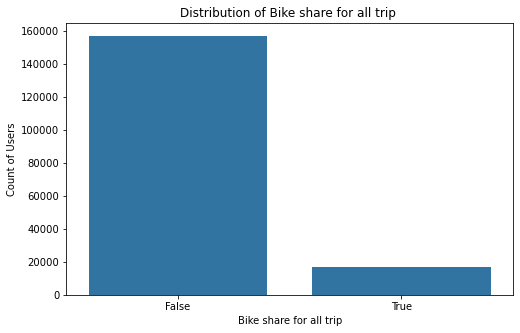

```python
# plotting bike_share_for_all_trip

plt.figure(figsize=[8,5])
base_color = sb.color_palette()[0]
sb.countplot(data = trip, x = 'bike_share_for_all_trip', color=base_color)
plt.title('Distribution of Bike share for all trip ')

# Labeling the axes
plt.xlabel('Bike share for all trip')
plt.ylabel('Count of Users')

# Dsiplay the plot
plt.show()
```

## Distribution of Gender

Gender of the user has 3 Qualitative variables which are Male, Female amnd others and from the next Plot we will found that The number of Male users are much larger than the both of number of Female and other users

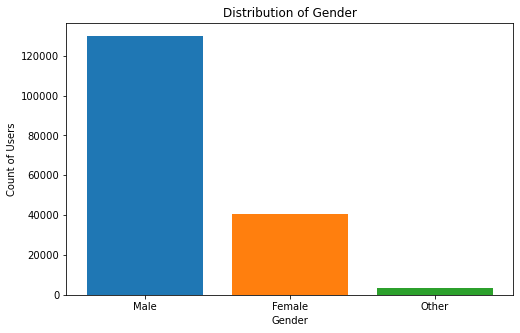

```python
# plotting gender
# choose the bar chart where the gender have Qualitative(Categorical) variables

plt.figure(figsize=[8,5])
plt.bar(x = trip['member_gender'].value_counts().keys(), height = trip['member_gender'].value_counts() , color = sb.color_palette(n_colors=9))
plt.title('Distribution of Gender')

# Labeling the axes
plt.xlabel('Gender')
plt.ylabel('Count of Users')

# Dsiplay the plot
plt.show()
```

## Distribution of Age

In the following Plot, we can see that the most users age are between 20 to 40 years old.

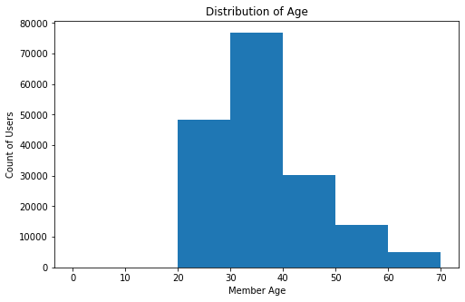

```python
# Plotting the age

bins = np.arange(0, trip['member_age'].max() + 10, 10)

plt.figure(figsize=[8,5])
plt.hist(data=trip, x='member_age', bins=bins);

plt.xticks(bins, bins)
plt.title('Distribution of Age')

# Labeling the axes
plt.xlabel('Member Age')
plt.ylabel('Count of Users')
```

## Distribution of Hours over Days

The trip distribution over hours peaks during rush hours of work between 8AM and 9AM and between 17PM to 18PM.

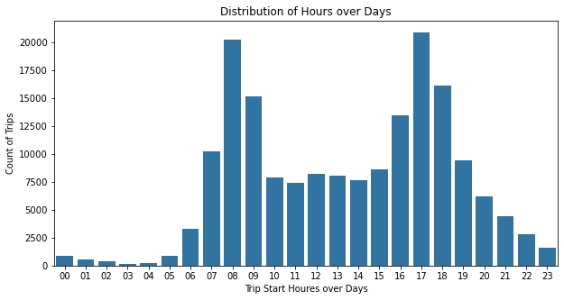

```python
# Sort the column values
trips1 = trip.copy()
trips1.sort_values(by=['start_hour_of_day'], inplace=True)


# Plotting
plt.figure(figsize=[10, 5])

base_color = sb.color_palette()[0]
sb.countplot(data= trips1 , x='start_hour_of_day', color= base_color)

plt.title('Distribution of Hours over Days')

# Labeling the axes
plt.xlabel('Trip Start Houres over Days')
plt.ylabel('Count of Trips')
```

## Distribution of Days over Week

The trip distribution over day of week, it is quite obvious that the most of trips happened on work days from Monday to Friday and many usage is probably for commuting and we can also see that The distribution decreases during holidays (the Weekends outside Egypt is during Saturday and Sunday).

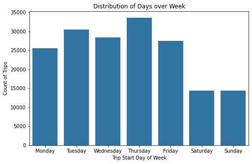

```python
# Returns the types for 'days' with the categories and orderedness
days = ['Monday', 'Tuesday', 'Wednesday', 'Thursday', 'Friday', 'Saturday', 'Sunday']
daycat = pd.api.types.CategoricalDtype(ordered=True, categories = days)
trip['start_day'] = trip['start_day'].astype(daycat)

# Plotting
plt.figure(figsize=[8, 5])

base_color = sb.color_palette()[0]
sb.countplot(data=trip, x='start_day', color= base_color)
plt.title('Distribution of Days over Week')

# Labeling the axes
plt.xlabel('Trip Start Day of Week')
plt.ylabel('Count of Trips')
```

## Trip Duration vs. Age

By investigating the next subplots, we can observe that most frequent Age of users is between 20 and 40.

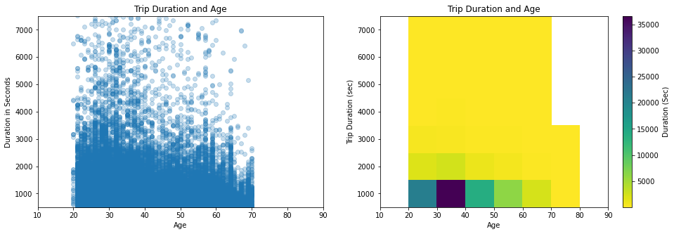

```python
# plotting Trip Duration and Age

plt.figure(figsize=[16,5])

plt.subplot(1, 2, 1)
plt.scatter(data = trip, x = 'member_age', y = 'duration_sec', alpha=1/4)
plt.title('Trip Duration and Age')
plt.axis([10, 90, 500, 7500])

# Labeling the axes
plt.xlabel('Age')
plt.ylabel('Duration in Seconds')

plt.subplot(1, 2, 2)
bins_y = np.arange(500, 8000, 1000)
bins_x = np.arange(10, 94, 10)

# Use cmin to set a minimum bound of counts
# Use cmap to reverse the color map.
plt.hist2d(data = trip, x = 'member_age', y = 'duration_sec', cmin = 0.5, cmap='viridis_r', bins = [bins_x, bins_y])
plt.colorbar(ticks=[5000, 10000 , 15000, 20000, 25000, 30000, 35000], label = 'Duration (Sec)')
plt.title('Trip Duration and Age')

# Labeling the axes
plt.xlabel('Age')
plt.ylabel('Trip Duration (sec)')

# Dsiplay the plot
plt.show()
```

## Distribution of day of week by user type and Distribution of hour of days by user type

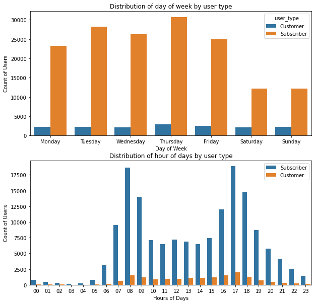

```python
plt.figure(figsize = [10, 10])

# subplot 1: start_day vs. user_type
plt.subplot(2, 1, 1)
sb.countplot(data = trip, x = 'start_day', hue = 'user_type')
plt.xlabel('Day of Week')
plt.ylabel('Count of Users')
plt.title('Distribution of day of week by user type')



# subplot 2: start_hour_of_day vs. user_type
ax = plt.subplot(2, 1, 2)

sb.countplot(data = trips1, x = 'start_hour_of_day', hue = 'user_type')
ax.legend()
plt.xlabel('Hours of Days')
plt.ylabel('Count of Users')
plt.title('Distribution of hour of days by user type')

plt.show()
```

## Hourly Usage during Weekdays by Customers and Subscribers

The next plot shows obviously very different usage between the two type of users. Subscribers use the system profusely on work days (Monday to Friday) while customers use it a lot on weekends, especially in the afternoon. Many trips concentrated around 8 and 8 AM and 17 and 18 PM on work days for subscribers when used for work transport, yet customers tend to use more in the late afternoon approx. 17 PM Monday to Friday.

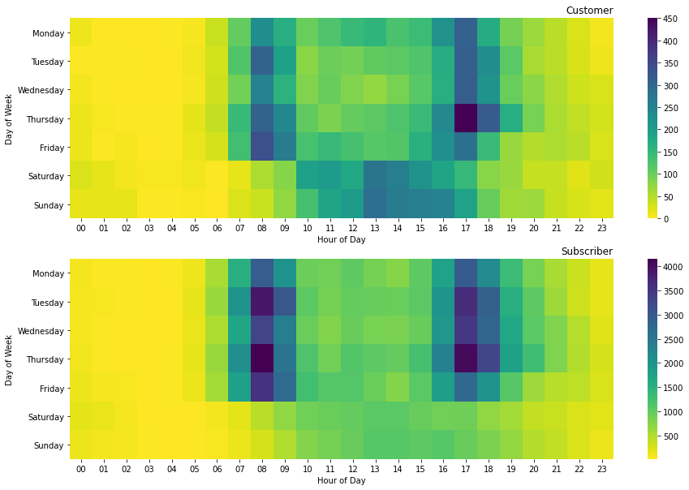

```python
# How does the hourly usage vary during weekdays for customers and subscribers?

plt.suptitle('Hourly Usage during Weekdays for Customers and Subscribers')
plt.figure(figsize = [15, 10])

# subplot 1
plt.subplot(2, 1, 1)
customers = trip.query('user_type == "Customer"')
ct_counts = customers.groupby(['start_day', 'start_hour_of_day']).size()
ct_counts = ct_counts.reset_index(name='count')
ct_counts = ct_counts.pivot(index='start_day', columns='start_hour_of_day', values='count')

sb.heatmap(ct_counts, cmap='viridis_r')

plt.title('Customer', loc='right')
plt.xlabel('Hour of Day')
plt.ylabel('Day of Week')

# subplot 2
plt.subplot(2, 1, 2)
sub = trip.query('user_type == "Subscriber"')
sub_counts = sub.groupby(['start_day', 'start_hour_of_day']).size()
sub_counts = sub_counts.reset_index(name='count')
sub_counts = sub_counts.pivot(index='start_day', columns='start_hour_of_day', values='count')

sb.heatmap(sub_counts, cmap='viridis_r')

plt.title('Subscriber', loc='right')
plt.xlabel('Hour of Day')
plt.ylabel('Day of Week')
```